# Risk Factor Analysis

## Outcome Variable

**Outcome Variable:** ever_stunted

## Predictor Variables

**Intervention Variable:** hhwealth_quart

**Adjustment Set:**

- arm
- sex
- W_mage
- meducyrs
- feducyrs
- W_gagebrth
- W_birthwt
- W_birthlen
- W_nchldlt5
- W_parity
- delta_sex
- delta_W_mage
- delta_meducyrs
- delta_feducyrs
- delta_W_gagebrth
- delta_W_birthwt
- delta_W_birthlen
- delta_W_nchldlt5
- delta_W_parity

## Stratifying Variables

The analysis was stratified on these variable(s):

- agecat
- studyid
- country

## Data Summary

| agecat | studyid | country | hhwealth_quart | ever_stunted | n_cell | n |
| --- | --- | --- | --- | --- | --- | --- |
| 0-24 months | ki0047075b-MAL-ED | BANGLADESH | Wealth Q4 | 0 | 30 | 242 |
| 0-24 months | ki0047075b-MAL-ED | BANGLADESH | Wealth Q4 | 1 | 31 | 242 |
| 0-24 months | ki0047075b-MAL-ED | BANGLADESH | Wealth Q1 | 0 | 24 | 242 |
| 0-24 months | ki0047075b-MAL-ED | BANGLADESH | Wealth Q1 | 1 | 36 | 242 |
| 0-24 months | ki0047075b-MAL-ED | BANGLADESH | Wealth Q2 | 0 | 17 | 242 |
| 0-24 months | ki0047075b-MAL-ED | BANGLADESH | Wealth Q2 | 1 | 44 | 242 |
| 0-24 months | ki0047075b-MAL-ED | BANGLADESH | Wealth Q3 | 0 | 22 | 242 |
| 0-24 months | ki0047075b-MAL-ED | BANGLADESH | Wealth Q3 | 1 | 38 | 242 |
| 0-24 months | ki0047075b-MAL-ED | BRAZIL | Wealth Q4 | 0 | 38 | 210 |
| 0-24 months | ki0047075b-MAL-ED | BRAZIL | Wealth Q4 | 1 | 15 | 210 |
| 0-24 months | ki0047075b-MAL-ED | BRAZIL | Wealth Q1 | 0 | 39 | 210 |
| 0-24 months | ki0047075b-MAL-ED | BRAZIL | Wealth Q1 | 1 | 14 | 210 |
| 0-24 months | ki0047075b-MAL-ED | BRAZIL | Wealth Q2 | 0 | 41 | 210 |
| 0-24 months | ki0047075b-MAL-ED | BRAZIL | Wealth Q2 | 1 | 12 | 210 |
| 0-24 months | ki0047075b-MAL-ED | BRAZIL | Wealth Q3 | 0 | 36 | 210 |
| 0-24 months | ki0047075b-MAL-ED | BRAZIL | Wealth Q3 | 1 | 15 | 210 |
| 0-24 months | ki0047075b-MAL-ED | INDIA | Wealth Q4 | 0 | 21 | 235 |
| 0-24 months | ki0047075b-MAL-ED | INDIA | Wealth Q4 | 1 | 38 | 235 |
| 0-24 months | ki0047075b-MAL-ED | INDIA | Wealth Q1 | 0 | 24 | 235 |
| 0-24 months | ki0047075b-MAL-ED | INDIA | Wealth Q1 | 1 | 36 | 235 |
| 0-24 months | ki0047075b-MAL-ED | INDIA | Wealth Q2 | 0 | 22 | 235 |
| 0-24 months | ki0047075b-MAL-ED | INDIA | Wealth Q2 | 1 | 36 | 235 |
| 0-24 months | ki0047075b-MAL-ED | INDIA | Wealth Q3 | 0 | 22 | 235 |
| 0-24 months | ki0047075b-MAL-ED | INDIA | Wealth Q3 | 1 | 36 | 235 |
| 0-24 months | ki0047075b-MAL-ED | NEPAL | Wealth Q4 | 0 | 41 | 236 |
| 0-24 months | ki0047075b-MAL-ED | NEPAL | Wealth Q4 | 1 | 18 | 236 |
| 0-24 months | ki0047075b-MAL-ED | NEPAL | Wealth Q1 | 0 | 39 | 236 |
| 0-24 months | ki0047075b-MAL-ED | NEPAL | Wealth Q1 | 1 | 20 | 236 |
| 0-24 months | ki0047075b-MAL-ED | NEPAL | Wealth Q2 | 0 | 41 | 236 |
| 0-24 months | ki0047075b-MAL-ED | NEPAL | Wealth Q2 | 1 | 18 | 236 |

[output cut: 402 more lines]

The following strata were considered:

- agecat: 0-24 months, studyid: ki0047075b-MAL-ED, country: BANGLADESH
- agecat: 0-24 months, studyid: ki0047075b-MAL-ED, country: BRAZIL
- agecat: 0-24 months, studyid: ki0047075b-MAL-ED, country: INDIA
- agecat: 0-24 months, studyid: ki0047075b-MAL-ED, country: NEPAL
- agecat: 0-24 months, studyid: ki0047075b-MAL-ED, country: PERU
- agecat: 0-24 months, studyid: ki0047075b-MAL-ED, country: SOUTH AFRICA
- agecat: 0-24 months, studyid: ki0047075b-MAL-ED, country: TANZANIA, UNITED REPUBLIC OF
- agecat: 0-24 months, studyid: ki1000108-CMC-V-BCS-2002, country: INDIA
- agecat: 0-24 months, studyid: ki1000108-IRC, country: INDIA
- agecat: 0-24 months, studyid: ki1017093b-PROVIDE, country: BANGLADESH
- agecat: 0-24 months, studyid: ki1066203-TanzaniaChild2, country: TANZANIA, UNITED REPUBLIC OF
- agecat: 0-24 months, studyid: ki1113344-GMS-Nepal, country: NEPAL
- agecat: 0-24 months, studyid: ki1114097-CONTENT, country: PERU
- agecat: 0-24 months, studyid: ki1135781-COHORTS, country: GUATEMALA
- agecat: 0-24 months, studyid: ki1135781-COHORTS, country: PHILIPPINES
- agecat: 0-24 months, studyid: ki1148112-LCNI-5, country: MALAWI
- agecat: 0-24 months, studyid: kiGH5241-JiVitA-3, country: BANGLADESH
- agecat: 0-24 months, studyid: kiGH5241-JiVitA-4, country: BANGLADESH
- agecat: 0-6 months, studyid: ki0047075b-MAL-ED, country: BANGLADESH
- agecat: 0-6 months, studyid: ki0047075b-MAL-ED, country: BRAZIL
- agecat: 0-6 months, studyid: ki0047075b-MAL-ED, country: INDIA
- agecat: 0-6 months, studyid: ki0047075b-MAL-ED, country: NEPAL
- agecat: 0-6 months, studyid: ki0047075b-MAL-ED, country: PERU
- agecat: 0-6 months, studyid: ki0047075b-MAL-ED, country: SOUTH AFRICA
- agecat: 0-6 months, studyid: ki0047075b-MAL-ED, country: TANZANIA, UNITED REPUBLIC OF
- agecat: 0-6 months, studyid: ki1000108-CMC-V-BCS-2002, country: INDIA
- agecat: 0-6 months, studyid: ki1000108-IRC, country: INDIA
- agecat: 0-6 months, studyid: ki1017093b-PROVIDE, country: BANGLADESH
- agecat: 0-6 months, studyid: ki1066203-TanzaniaChild2, country: TANZANIA, UNITED REPUBLIC OF
- agecat: 0-6 months, studyid: ki1113344-GMS-Nepal, country: NEPAL
- agecat: 0-6 months, studyid: ki1114097-CONTENT, country: PERU
- agecat: 0-6 months, studyid: ki1135781-COHORTS, country: GUATEMALA
- agecat: 0-6 months, studyid: ki1135781-COHORTS, country: PHILIPPINES
- agecat: 0-6 months, studyid: ki1148112-LCNI-5, country: MALAWI
- agecat: 0-6 months, studyid: kiGH5241-JiVitA-3, country: BANGLADESH
- agecat: 0-6 months, studyid: kiGH5241-JiVitA-4, country: BANGLADESH
- agecat: 6-24 months, studyid: ki0047075b-MAL-ED, country: BANGLADESH
- agecat: 6-24 months, studyid: ki0047075b-MAL-ED, country: BRAZIL
- agecat: 6-24 months, studyid: ki0047075b-MAL-ED, country: INDIA
- agecat: 6-24 months, studyid: ki0047075b-MAL-ED, country: NEPAL
- agecat: 6-24 months, studyid: ki0047075b-MAL-ED, country: PERU
- agecat: 6-24 months, studyid: ki0047075b-MAL-ED, country: SOUTH AFRICA
- agecat: 6-24 months, studyid: ki0047075b-MAL-ED, country: TANZANIA, UNITED REPUBLIC OF
- agecat: 6-24 months, studyid: ki1000108-CMC-V-BCS-2002, country: INDIA
- agecat: 6-24 months, studyid: ki1000108-IRC, country: INDIA
- agecat: 6-24 months, studyid: ki1017093b-PROVIDE, country: BANGLADESH
- agecat: 6-24 months, studyid: ki1066203-TanzaniaChild2, country: TANZANIA, UNITED REPUBLIC OF
- agecat: 6-24 months, studyid: ki1113344-GMS-Nepal, country: NEPAL
- agecat: 6-24 months, studyid: ki1114097-CONTENT, country: PERU
- agecat: 6-24 months, studyid: ki1135781-COHORTS, country: GUATEMALA
- agecat: 6-24 months, studyid: ki1135781-COHORTS, country: PHILIPPINES
- agecat: 6-24 months, studyid: ki1148112-LCNI-5, country: MALAWI
- agecat: 6-24 months, studyid: kiGH5241-JiVitA-3, country: BANGLADESH
- agecat: 6-24 months, studyid: kiGH5241-JiVitA-4, country: BANGLADESH

### Dropped Strata

Some strata were dropped due to rare outcomes:

- agecat: 0-24 months, studyid: ki0047075b-MAL-ED, country: TANZANIA, UNITED REPUBLIC OF
- agecat: 6-24 months, studyid: ki0047075b-MAL-ED, country: BRAZIL
- agecat: 6-24 months, studyid: ki0047075b-MAL-ED, country: TANZANIA, UNITED REPUBLIC OF
- agecat: 6-24 months, studyid: ki1114097-CONTENT, country: PERU

## Methods Detail

We’re interested in the causal parameters $E[Y_a]$ for all values of $a \in \mathcal{A}$. These parameters represent the mean outcome if, possibly contrary to fact, we intervened to set all units to have $A=a$. Under the randomization and positivity assumptions, these are identified by the statistical parameters $\psi_a=E_W[E_{Y|A,W}(Y|A=a,W)]$. In addition, we’re interested in the mean of $Y$, $E[Y]$ under no intervention (the observed mean). We will estimate these parameters by using SuperLearner to fit the relevant likelihood factors – $E_{Y|A,W}(Y|A=a,W)$ and $p(A=a|W)$, and then updating our likelihood fit using a joint TMLE.

For unadjusted analyses ($W=\{\}$), initial likelihoods were estimated using Lrnr_glm to estimate the simple $E(Y|A)$ and Lrnr_mean to estimate $p(A)$. For adjusted analyses, a small library containing Lrnr_glmnet, Lrnr_xgboost, and Lrnr_mean was used.

Having estimated these parameters, we will then use the delta method to estimate relative risks and attributable risks relative to a prespecified baseline level of $A$.

# Results Detail

## Results Plots

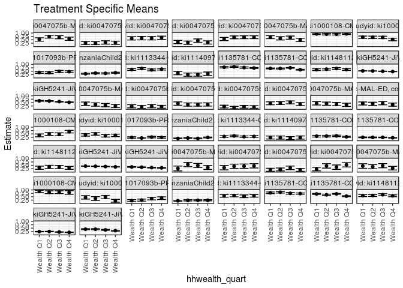

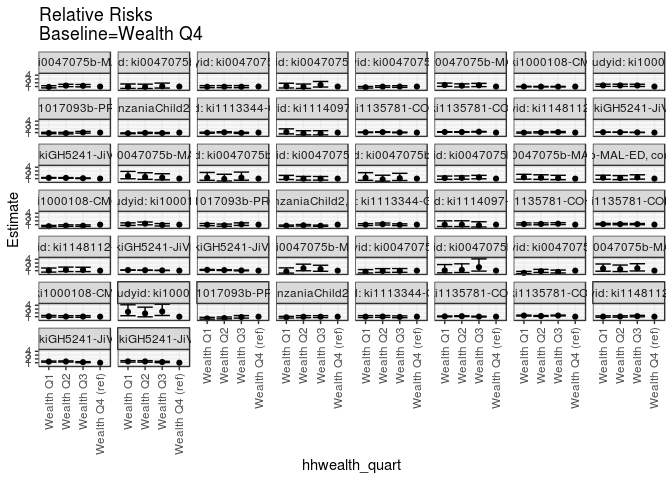

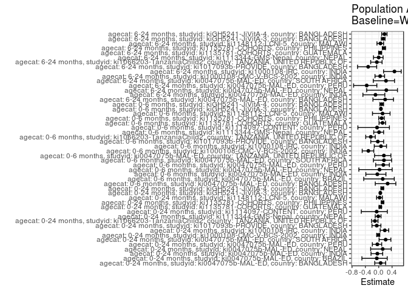

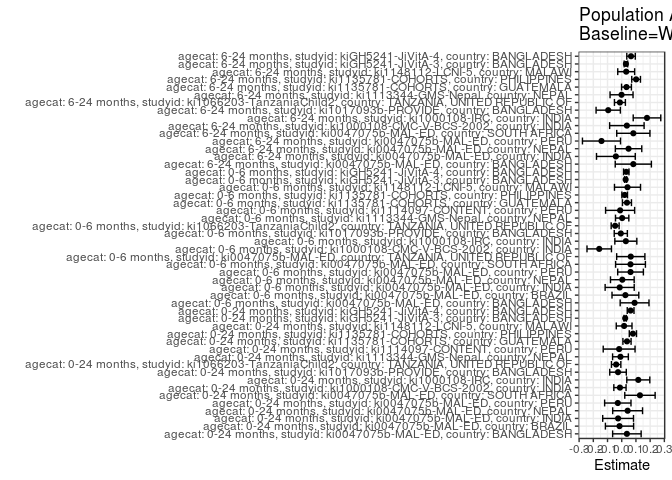

## Results Table

### Parameter: TSM

| agecat | studyid | country | intervention_level | baseline_level | estimate | ci_lower | ci_upper |
| --- | --- | --- | --- | --- | --- | --- | --- |
| 0-24 months | ki0047075b-MAL-ED | BANGLADESH | Wealth Q4 | NA | 0.5793738 | 0.4612824 | 0.6974653 |
| 0-24 months | ki0047075b-MAL-ED | BANGLADESH | Wealth Q1 | NA | 0.5234439 | 0.3977979 | 0.6490899 |
| 0-24 months | ki0047075b-MAL-ED | BANGLADESH | Wealth Q2 | NA | 0.7275665 | 0.6230774 | 0.8320555 |
| 0-24 months | ki0047075b-MAL-ED | BANGLADESH | Wealth Q3 | NA | 0.6927044 | 0.5772481 | 0.8081607 |
| 0-24 months | ki0047075b-MAL-ED | BRAZIL | Wealth Q4 | NA | 0.2822617 | 0.1636786 | 0.4008448 |
| 0-24 months | ki0047075b-MAL-ED | BRAZIL | Wealth Q1 | NA | 0.2656142 | 0.1557182 | 0.3755102 |
| 0-24 months | ki0047075b-MAL-ED | BRAZIL | Wealth Q2 | NA | 0.2554570 | 0.1439336 | 0.3669803 |
| 0-24 months | ki0047075b-MAL-ED | BRAZIL | Wealth Q3 | NA | 0.3058793 | 0.1820401 | 0.4297185 |
| 0-24 months | ki0047075b-MAL-ED | INDIA | Wealth Q4 | NA | 0.6468016 | 0.5215009 | 0.7721022 |
| 0-24 months | ki0047075b-MAL-ED | INDIA | Wealth Q1 | NA | 0.6077728 | 0.4847382 | 0.7308074 |
| 0-24 months | ki0047075b-MAL-ED | INDIA | Wealth Q2 | NA | 0.6209360 | 0.4937449 | 0.7481271 |
| 0-24 months | ki0047075b-MAL-ED | INDIA | Wealth Q3 | NA | 0.6146934 | 0.4892770 | 0.7401097 |
| 0-24 months | ki0047075b-MAL-ED | NEPAL | Wealth Q4 | NA | 0.3059195 | 0.1857684 | 0.4260707 |
| 0-24 months | ki0047075b-MAL-ED | NEPAL | Wealth Q1 | NA | 0.3357070 | 0.2144924 | 0.4569215 |
| 0-24 months | ki0047075b-MAL-ED | NEPAL | Wealth Q2 | NA | 0.2883390 | 0.1672488 | 0.4094292 |
| 0-24 months | ki0047075b-MAL-ED | NEPAL | Wealth Q3 | NA | 0.4398457 | 0.3128735 | 0.5668179 |
| 0-24 months | ki0047075b-MAL-ED | PERU | Wealth Q4 | NA | 0.6930306 | 0.5859040 | 0.8001572 |
| 0-24 months | ki0047075b-MAL-ED | PERU | Wealth Q1 | NA | 0.5581829 | 0.4411072 | 0.6752586 |
| 0-24 months | ki0047075b-MAL-ED | PERU | Wealth Q2 | NA | 0.6821538 | 0.5772508 | 0.7870568 |
| 0-24 months | ki0047075b-MAL-ED | PERU | Wealth Q3 | NA | 0.6910283 | 0.5824503 | 0.7996063 |
| 0-24 months | ki0047075b-MAL-ED | SOUTH AFRICA | Wealth Q4 | NA | 0.4904095 | 0.3653728 | 0.6154463 |
| 0-24 months | ki0047075b-MAL-ED | SOUTH AFRICA | Wealth Q1 | NA | 0.6970919 | 0.5837911 | 0.8103928 |
| 0-24 months | ki0047075b-MAL-ED | SOUTH AFRICA | Wealth Q2 | NA | 0.6078049 | 0.4882501 | 0.7273597 |
| 0-24 months | ki0047075b-MAL-ED | SOUTH AFRICA | Wealth Q3 | NA | 0.6610242 | 0.5439415 | 0.7781068 |
| 0-24 months | ki1000108-CMC-V-BCS-2002 | INDIA | Wealth Q4 | NA | 0.9375000 | 0.8890135 | 0.9859865 |
| 0-24 months | ki1000108-CMC-V-BCS-2002 | INDIA | Wealth Q1 | NA | 0.9340659 | 0.8830091 | 0.9851228 |
| 0-24 months | ki1000108-CMC-V-BCS-2002 | INDIA | Wealth Q2 | NA | 0.9157895 | 0.8598717 | 0.9717073 |
| 0-24 months | ki1000108-CMC-V-BCS-2002 | INDIA | Wealth Q3 | NA | 0.9120879 | 0.8538303 | 0.9703456 |
| 0-24 months | ki1000108-IRC | INDIA | Wealth Q4 | NA | 0.5248522 | 0.4297648 | 0.6199396 |
| 0-24 months | ki1000108-IRC | INDIA | Wealth Q1 | NA | 0.6919623 | 0.6055721 | 0.7783524 |

[output cut: 170 more lines]

### Parameter: E(Y)

| agecat | studyid | country | intervention_level | baseline_level | estimate | ci_lower | ci_upper |
| --- | --- | --- | --- | --- | --- | --- | --- |
| 0-24 months | ki0047075b-MAL-ED | BANGLADESH | NA | NA | 0.6157025 | 0.5542897 | 0.6771153 |
| 0-24 months | ki0047075b-MAL-ED | BRAZIL | NA | NA | 0.2666667 | 0.2067138 | 0.3266195 |
| 0-24 months | ki0047075b-MAL-ED | INDIA | NA | NA | 0.6212766 | 0.5591262 | 0.6834270 |
| 0-24 months | ki0047075b-MAL-ED | NEPAL | NA | NA | 0.3474576 | 0.2865784 | 0.4083369 |
| 0-24 months | ki0047075b-MAL-ED | PERU | NA | NA | 0.6654412 | 0.6092647 | 0.7216177 |
| 0-24 months | ki0047075b-MAL-ED | SOUTH AFRICA | NA | NA | 0.6186770 | 0.5591785 | 0.6781756 |
| 0-24 months | ki1000108-CMC-V-BCS-2002 | INDIA | NA | NA | 0.9249330 | 0.8981563 | 0.9517096 |
| 0-24 months | ki1000108-IRC | INDIA | NA | NA | 0.6414634 | 0.5949863 | 0.6879405 |
| 0-24 months | ki1017093b-PROVIDE | BANGLADESH | NA | NA | 0.4357143 | 0.3989556 | 0.4724730 |
| 0-24 months | ki1066203-TanzaniaChild2 | TANZANIA, UNITED REPUBLIC OF | NA | NA | 0.3468960 | 0.3277853 | 0.3660067 |
| 0-24 months | ki1113344-GMS-Nepal | NEPAL | NA | NA | 0.6389685 | 0.6033115 | 0.6746254 |
| 0-24 months | ki1114097-CONTENT | PERU | NA | NA | 0.2930233 | 0.2320422 | 0.3540043 |
| 0-24 months | ki1135781-COHORTS | GUATEMALA | NA | NA | 0.7715180 | 0.7484902 | 0.7945458 |
| 0-24 months | ki1135781-COHORTS | PHILIPPINES | NA | NA | 0.6866209 | 0.6701747 | 0.7030670 |
| 0-24 months | ki1148112-LCNI-5 | MALAWI | NA | NA | 0.6376989 | 0.6047193 | 0.6706785 |
| 0-24 months | kiGH5241-JiVitA-3 | BANGLADESH | NA | NA | 0.4954233 | 0.4875870 | 0.5032596 |
| 0-24 months | kiGH5241-JiVitA-4 | BANGLADESH | NA | NA | 0.5818282 | 0.5658219 | 0.5978346 |
| 0-6 months | ki0047075b-MAL-ED | BANGLADESH | NA | NA | 0.3388430 | 0.2790857 | 0.3986003 |
| 0-6 months | ki0047075b-MAL-ED | BRAZIL | NA | NA | 0.2142857 | 0.1586564 | 0.2699151 |
| 0-6 months | ki0047075b-MAL-ED | INDIA | NA | NA | 0.3446809 | 0.2837868 | 0.4055749 |
| 0-6 months | ki0047075b-MAL-ED | NEPAL | NA | NA | 0.1737288 | 0.1252880 | 0.2221696 |
| 0-6 months | ki0047075b-MAL-ED | PERU | NA | NA | 0.4485294 | 0.3893160 | 0.5077428 |
| 0-6 months | ki0047075b-MAL-ED | SOUTH AFRICA | NA | NA | 0.3929961 | 0.3331663 | 0.4528260 |
| 0-6 months | ki0047075b-MAL-ED | TANZANIA, UNITED REPUBLIC OF | NA | NA | 0.4120000 | 0.3508656 | 0.4731344 |
| 0-6 months | ki1000108-CMC-V-BCS-2002 | INDIA | NA | NA | 0.5108696 | 0.4597270 | 0.5620121 |
| 0-6 months | ki1000108-IRC | INDIA | NA | NA | 0.4243902 | 0.3764905 | 0.4722900 |
| 0-6 months | ki1017093b-PROVIDE | BANGLADESH | NA | NA | 0.2400000 | 0.2083392 | 0.2716608 |
| 0-6 months | ki1066203-TanzaniaChild2 | TANZANIA, UNITED REPUBLIC OF | NA | NA | 0.1950503 | 0.1791413 | 0.2109594 |
| 0-6 months | ki1113344-GMS-Nepal | NEPAL | NA | NA | 0.3180516 | 0.2834770 | 0.3526261 |
| 0-6 months | ki1114097-CONTENT | PERU | NA | NA | 0.2232558 | 0.1674626 | 0.2790491 |
| 0-6 months | ki1135781-COHORTS | GUATEMALA | NA | NA | 0.3240116 | 0.2955133 | 0.3525098 |
| 0-6 months | ki1135781-COHORTS | PHILIPPINES | NA | NA | 0.2391233 | 0.2240003 | 0.2542464 |
| 0-6 months | ki1148112-LCNI-5 | MALAWI | NA | NA | 0.3531599 | 0.2959376 | 0.4103821 |
| 0-6 months | kiGH5241-JiVitA-3 | BANGLADESH | NA | NA | 0.4130891 | 0.4056400 | 0.4205383 |
| 0-6 months | kiGH5241-JiVitA-4 | BANGLADESH | NA | NA | 0.3474692 | 0.3322601 | 0.3626783 |
| 6-24 months | ki0047075b-MAL-ED | BANGLADESH | NA | NA | 0.4240506 | 0.3467471 | 0.5013542 |
| 6-24 months | ki0047075b-MAL-ED | INDIA | NA | NA | 0.4220779 | 0.3438191 | 0.5003367 |
| 6-24 months | ki0047075b-MAL-ED | NEPAL | NA | NA | 0.2113402 | 0.1537425 | 0.2689379 |
| 6-24 months | ki0047075b-MAL-ED | PERU | NA | NA | 0.3959732 | 0.3171819 | 0.4747644 |
| 6-24 months | ki0047075b-MAL-ED | SOUTH AFRICA | NA | NA | 0.3741935 | 0.2977649 | 0.4506221 |
| 6-24 months | ki1000108-CMC-V-BCS-2002 | INDIA | NA | NA | 0.8486486 | 0.7968646 | 0.9004327 |
| 6-24 months | ki1000108-IRC | INDIA | NA | NA | 0.3771186 | 0.3151523 | 0.4390850 |
| 6-24 months | ki1017093b-PROVIDE | BANGLADESH | NA | NA | 0.3004386 | 0.2583143 | 0.3425629 |
| 6-24 months | ki1066203-TanzaniaChild2 | TANZANIA, UNITED REPUBLIC OF | NA | NA | 0.2268170 | 0.2062654 | 0.2473687 |
| 6-24 months | ki1113344-GMS-Nepal | NEPAL | NA | NA | 0.5642317 | 0.5153938 | 0.6130696 |
| 6-24 months | ki1135781-COHORTS | GUATEMALA | NA | NA | 0.7665094 | 0.7380190 | 0.7949999 |
| 6-24 months | ki1135781-COHORTS | PHILIPPINES | NA | NA | 0.6449788 | 0.6246093 | 0.6653483 |
| 6-24 months | ki1148112-LCNI-5 | MALAWI | NA | NA | 0.6000000 | 0.5639396 | 0.6360604 |
| 6-24 months | kiGH5241-JiVitA-3 | BANGLADESH | NA | NA | 0.2161518 | 0.2067762 | 0.2255274 |
| 6-24 months | kiGH5241-JiVitA-4 | BANGLADESH | NA | NA | 0.3784303 | 0.3598372 | 0.3970234 |

### Parameter: RR

| agecat | studyid | country | intervention_level | baseline_level | estimate | ci_lower | ci_upper |
| --- | --- | --- | --- | --- | --- | --- | --- |
| 0-24 months | ki0047075b-MAL-ED | BANGLADESH | Wealth Q4 | Wealth Q4 | 1.0000000 | 1.0000000 | 1.0000000 |
| 0-24 months | ki0047075b-MAL-ED | BANGLADESH | Wealth Q1 | Wealth Q4 | 0.9034649 | 0.6623422 | 1.2323672 |
| 0-24 months | ki0047075b-MAL-ED | BANGLADESH | Wealth Q2 | Wealth Q4 | 1.2557807 | 0.9864414 | 1.5986607 |
| 0-24 months | ki0047075b-MAL-ED | BANGLADESH | Wealth Q3 | Wealth Q4 | 1.1956087 | 0.9248725 | 1.5455971 |
| 0-24 months | ki0047075b-MAL-ED | BRAZIL | Wealth Q4 | Wealth Q4 | 1.0000000 | 1.0000000 | 1.0000000 |
| 0-24 months | ki0047075b-MAL-ED | BRAZIL | Wealth Q1 | Wealth Q4 | 0.9410211 | 0.5278191 | 1.6776975 |
| 0-24 months | ki0047075b-MAL-ED | BRAZIL | Wealth Q2 | Wealth Q4 | 0.9050359 | 0.4992608 | 1.6406056 |
| 0-24 months | ki0047075b-MAL-ED | BRAZIL | Wealth Q3 | Wealth Q4 | 1.0836729 | 0.6116007 | 1.9201204 |
| 0-24 months | ki0047075b-MAL-ED | INDIA | Wealth Q4 | Wealth Q4 | 1.0000000 | 1.0000000 | 1.0000000 |
| 0-24 months | ki0047075b-MAL-ED | INDIA | Wealth Q1 | Wealth Q4 | 0.9396588 | 0.7107786 | 1.2422416 |
| 0-24 months | ki0047075b-MAL-ED | INDIA | Wealth Q2 | Wealth Q4 | 0.9600100 | 0.7240210 | 1.2729179 |
| 0-24 months | ki0047075b-MAL-ED | INDIA | Wealth Q3 | Wealth Q4 | 0.9503585 | 0.7174118 | 1.2589441 |
| 0-24 months | ki0047075b-MAL-ED | NEPAL | Wealth Q4 | Wealth Q4 | 1.0000000 | 1.0000000 | 1.0000000 |
| 0-24 months | ki0047075b-MAL-ED | NEPAL | Wealth Q1 | Wealth Q4 | 1.0973700 | 0.6430483 | 1.8726757 |
| 0-24 months | ki0047075b-MAL-ED | NEPAL | Wealth Q2 | Wealth Q4 | 0.9425322 | 0.5305305 | 1.6744878 |
| 0-24 months | ki0047075b-MAL-ED | NEPAL | Wealth Q3 | Wealth Q4 | 1.4377822 | 0.8825935 | 2.3422084 |
| 0-24 months | ki0047075b-MAL-ED | PERU | Wealth Q4 | Wealth Q4 | 1.0000000 | 1.0000000 | 1.0000000 |
| 0-24 months | ki0047075b-MAL-ED | PERU | Wealth Q1 | Wealth Q4 | 0.8054232 | 0.6220775 | 1.0428067 |
| 0-24 months | ki0047075b-MAL-ED | PERU | Wealth Q2 | Wealth Q4 | 0.9843055 | 0.7938780 | 1.2204109 |
| 0-24 months | ki0047075b-MAL-ED | PERU | Wealth Q3 | Wealth Q4 | 0.9971108 | 0.8026168 | 1.2387356 |
| 0-24 months | ki0047075b-MAL-ED | SOUTH AFRICA | Wealth Q4 | Wealth Q4 | 1.0000000 | 1.0000000 | 1.0000000 |
| 0-24 months | ki0047075b-MAL-ED | SOUTH AFRICA | Wealth Q1 | Wealth Q4 | 1.4214485 | 1.0514686 | 1.9216132 |
| 0-24 months | ki0047075b-MAL-ED | SOUTH AFRICA | Wealth Q2 | Wealth Q4 | 1.2393823 | 0.8984144 | 1.7097550 |
| 0-24 months | ki0047075b-MAL-ED | SOUTH AFRICA | Wealth Q3 | Wealth Q4 | 1.3479023 | 0.9884707 | 1.8380318 |
| 0-24 months | ki1000108-CMC-V-BCS-2002 | INDIA | Wealth Q4 | Wealth Q4 | 1.0000000 | 1.0000000 | 1.0000000 |
| 0-24 months | ki1000108-CMC-V-BCS-2002 | INDIA | Wealth Q1 | Wealth Q4 | 0.9963370 | 0.9241135 | 1.0742051 |
| 0-24 months | ki1000108-CMC-V-BCS-2002 | INDIA | Wealth Q2 | Wealth Q4 | 0.9768421 | 0.9017212 | 1.0582212 |
| 0-24 months | ki1000108-CMC-V-BCS-2002 | INDIA | Wealth Q3 | Wealth Q4 | 0.9728938 | 0.8961328 | 1.0562300 |
| 0-24 months | ki1000108-IRC | INDIA | Wealth Q4 | Wealth Q4 | 1.0000000 | 1.0000000 | 1.0000000 |
| 0-24 months | ki1000108-IRC | INDIA | Wealth Q1 | Wealth Q4 | 1.3183946 | 1.0608459 | 1.6384703 |

[output cut: 170 more lines]

### Parameter: PAR

| agecat | studyid | country | intervention_level | baseline_level | estimate | ci_lower | ci_upper |
| --- | --- | --- | --- | --- | --- | --- | --- |
| 0-24 months | ki0047075b-MAL-ED | BANGLADESH | Wealth Q4 | NA | 0.0363286 | -0.0639724 | 0.1366296 |
| 0-24 months | ki0047075b-MAL-ED | BRAZIL | Wealth Q4 | NA | -0.0155950 | -0.1148770 | 0.0836870 |
| 0-24 months | ki0047075b-MAL-ED | INDIA | Wealth Q4 | NA | -0.0255250 | -0.1339402 | 0.0828903 |
| 0-24 months | ki0047075b-MAL-ED | NEPAL | Wealth Q4 | NA | 0.0415381 | -0.0636086 | 0.1466847 |
| 0-24 months | ki0047075b-MAL-ED | PERU | Wealth Q4 | NA | -0.0275894 | -0.1203627 | 0.0651839 |
| 0-24 months | ki0047075b-MAL-ED | SOUTH AFRICA | Wealth Q4 | NA | 0.1282675 | 0.0214101 | 0.2351249 |
| 0-24 months | ki1000108-CMC-V-BCS-2002 | INDIA | Wealth Q4 | NA | -0.0125670 | -0.0556692 | 0.0305351 |
| 0-24 months | ki1000108-IRC | INDIA | Wealth Q4 | NA | 0.1166112 | 0.0355401 | 0.1976824 |
| 0-24 months | ki1017093b-PROVIDE | BANGLADESH | Wealth Q4 | NA | -0.0261417 | -0.0844286 | 0.0321452 |
| 0-24 months | ki1066203-TanzaniaChild2 | TANZANIA, UNITED REPUBLIC OF | Wealth Q4 | NA | -0.0393006 | -0.0722661 | -0.0063351 |
| 0-24 months | ki1113344-GMS-Nepal | NEPAL | Wealth Q4 | NA | -0.0088776 | -0.0642765 | 0.0465213 |
| 0-24 months | ki1114097-CONTENT | PERU | Wealth Q4 | NA | -0.0182922 | -0.1303008 | 0.0937164 |
| 0-24 months | ki1135781-COHORTS | GUATEMALA | Wealth Q4 | NA | 0.0370867 | 0.0083201 | 0.0658534 |
| 0-24 months | ki1135781-COHORTS | PHILIPPINES | Wealth Q4 | NA | 0.0787183 | 0.0533479 | 0.1040887 |
| 0-24 months | ki1148112-LCNI-5 | MALAWI | Wealth Q4 | NA | 0.0168764 | -0.0385158 | 0.0722687 |
| 0-24 months | kiGH5241-JiVitA-3 | BANGLADESH | Wealth Q4 | NA | 0.0242817 | 0.0158473 | 0.0327161 |
| 0-24 months | kiGH5241-JiVitA-4 | BANGLADESH | Wealth Q4 | NA | 0.0625487 | 0.0387983 | 0.0862991 |
| 0-6 months | ki0047075b-MAL-ED | BANGLADESH | Wealth Q4 | NA | 0.0904614 | -0.0109629 | 0.1918856 |
| 0-6 months | ki0047075b-MAL-ED | BRAZIL | Wealth Q4 | NA | 0.0258149 | -0.0684380 | 0.1200678 |
| 0-6 months | ki0047075b-MAL-ED | INDIA | Wealth Q4 | NA | -0.0144841 | -0.1168059 | 0.0878377 |
| 0-6 months | ki0047075b-MAL-ED | NEPAL | Wealth Q4 | NA | 0.0042373 | -0.0791207 | 0.0875953 |
| 0-6 months | ki0047075b-MAL-ED | PERU | Wealth Q4 | NA | 0.0620279 | -0.0284088 | 0.1524645 |
| 0-6 months | ki0047075b-MAL-ED | SOUTH AFRICA | Wealth Q4 | NA | 0.0617756 | -0.0431332 | 0.1666843 |
| 0-6 months | ki0047075b-MAL-ED | TANZANIA, UNITED REPUBLIC OF | Wealth Q4 | NA | 0.0636856 | -0.0356465 | 0.1630178 |
| 0-6 months | ki1000108-CMC-V-BCS-2002 | INDIA | Wealth Q4 | NA | -0.1583761 | -0.2444840 | -0.0722683 |
| 0-6 months | ki1000108-IRC | INDIA | Wealth Q4 | NA | 0.0288830 | -0.0485297 | 0.1062958 |
| 0-6 months | ki1017093b-PROVIDE | BANGLADESH | Wealth Q4 | NA | -0.0065835 | -0.0526838 | 0.0395167 |
| 0-6 months | ki1066203-TanzaniaChild2 | TANZANIA, UNITED REPUBLIC OF | Wealth Q4 | NA | -0.0463161 | -0.0742565 | -0.0183758 |
| 0-6 months | ki1113344-GMS-Nepal | NEPAL | Wealth Q4 | NA | 0.0030858 | -0.0437751 | 0.0499468 |
| 0-6 months | ki1114097-CONTENT | PERU | Wealth Q4 | NA | -0.0113296 | -0.1135528 | 0.0908935 |
| 0-6 months | ki1135781-COHORTS | GUATEMALA | Wealth Q4 | NA | 0.0368359 | 0.0051252 | 0.0685467 |
| 0-6 months | ki1135781-COHORTS | PHILIPPINES | Wealth Q4 | NA | 0.0207841 | 0.0010219 | 0.0405464 |
| 0-6 months | ki1148112-LCNI-5 | MALAWI | Wealth Q4 | NA | 0.0406376 | -0.0510306 | 0.1323057 |
| 0-6 months | kiGH5241-JiVitA-3 | BANGLADESH | Wealth Q4 | NA | 0.0274531 | 0.0201120 | 0.0347941 |
| 0-6 months | kiGH5241-JiVitA-4 | BANGLADESH | Wealth Q4 | NA | 0.0319046 | 0.0128299 | 0.0509793 |
| 6-24 months | ki0047075b-MAL-ED | BANGLADESH | Wealth Q4 | NA | 0.0815377 | -0.0456901 | 0.2087655 |
| 6-24 months | ki0047075b-MAL-ED | INDIA | Wealth Q4 | NA | -0.0411369 | -0.1775831 | 0.0953093 |
| 6-24 months | ki0047075b-MAL-ED | NEPAL | Wealth Q4 | NA | 0.0480749 | -0.0449018 | 0.1410516 |
| 6-24 months | ki0047075b-MAL-ED | PERU | Wealth Q4 | NA | -0.1424884 | -0.2764712 | -0.0085056 |
| 6-24 months | ki0047075b-MAL-ED | SOUTH AFRICA | Wealth Q4 | NA | 0.0817034 | -0.0352063 | 0.1986131 |
| 6-24 months | ki1000108-CMC-V-BCS-2002 | INDIA | Wealth Q4 | NA | 0.0361486 | -0.0851282 | 0.1574255 |
| 6-24 months | ki1000108-IRC | INDIA | Wealth Q4 | NA | 0.1778595 | 0.0808542 | 0.2748649 |
| 6-24 months | ki1017093b-PROVIDE | BANGLADESH | Wealth Q4 | NA | -0.0950303 | -0.1805708 | -0.0094897 |
| 6-24 months | ki1066203-TanzaniaChild2 | TANZANIA, UNITED REPUBLIC OF | Wealth Q4 | NA | -0.0127342 | -0.0512854 | 0.0258169 |
| 6-24 months | ki1113344-GMS-Nepal | NEPAL | Wealth Q4 | NA | -0.0012957 | -0.0821961 | 0.0796047 |
| 6-24 months | ki1135781-COHORTS | GUATEMALA | Wealth Q4 | NA | 0.0334846 | -0.0011881 | 0.0681572 |
| 6-24 months | ki1135781-COHORTS | PHILIPPINES | Wealth Q4 | NA | 0.1011862 | 0.0705220 | 0.1318504 |
| 6-24 months | ki1148112-LCNI-5 | MALAWI | Wealth Q4 | NA | 0.0314329 | -0.0280603 | 0.0909261 |
| 6-24 months | kiGH5241-JiVitA-3 | BANGLADESH | Wealth Q4 | NA | 0.0294761 | 0.0171202 | 0.0418320 |
| 6-24 months | kiGH5241-JiVitA-4 | BANGLADESH | Wealth Q4 | NA | 0.0655422 | 0.0356283 | 0.0954561 |

### Parameter: PAF

| agecat | studyid | country | intervention_level | baseline_level | estimate | ci_lower | ci_upper |
| --- | --- | --- | --- | --- | --- | --- | --- |
| 0-24 months | ki0047075b-MAL-ED | BANGLADESH | Wealth Q4 | NA | 0.0590036 | -0.1190436 | 0.2087222 |
| 0-24 months | ki0047075b-MAL-ED | BRAZIL | Wealth Q4 | NA | -0.0584813 | -0.5040395 | 0.2550843 |
| 0-24 months | ki0047075b-MAL-ED | INDIA | Wealth Q4 | NA | -0.0410847 | -0.2310932 | 0.1195977 |
| 0-24 months | ki0047075b-MAL-ED | NEPAL | Wealth Q4 | NA | 0.1195486 | -0.2418524 | 0.3757755 |
| 0-24 months | ki0047075b-MAL-ED | PERU | Wealth Q4 | NA | -0.0414603 | -0.1907990 | 0.0891497 |
| 0-24 months | ki0047075b-MAL-ED | SOUTH AFRICA | Wealth Q4 | NA | 0.2073254 | 0.0116097 | 0.3642866 |
| 0-24 months | ki1000108-CMC-V-BCS-2002 | INDIA | Wealth Q4 | NA | -0.0135870 | -0.0613168 | 0.0319963 |
| 0-24 months | ki1000108-IRC | INDIA | Wealth Q4 | NA | 0.1817894 | 0.0436957 | 0.2999419 |
| 0-24 months | ki1017093b-PROVIDE | BANGLADESH | Wealth Q4 | NA | -0.0599973 | -0.2025363 | 0.0656463 |
| 0-24 months | ki1066203-TanzaniaChild2 | TANZANIA, UNITED REPUBLIC OF | Wealth Q4 | NA | -0.1132921 | -0.2125350 | -0.0221719 |
| 0-24 months | ki1113344-GMS-Nepal | NEPAL | Wealth Q4 | NA | -0.0138936 | -0.1044279 | 0.0692193 |
| 0-24 months | ki1114097-CONTENT | PERU | Wealth Q4 | NA | -0.0624257 | -0.5223073 | 0.2585279 |
| 0-24 months | ki1135781-COHORTS | GUATEMALA | Wealth Q4 | NA | 0.0480698 | 0.0098763 | 0.0847900 |
| 0-24 months | ki1135781-COHORTS | PHILIPPINES | Wealth Q4 | NA | 0.1146460 | 0.0766101 | 0.1511151 |
| 0-24 months | ki1148112-LCNI-5 | MALAWI | Wealth Q4 | NA | 0.0264646 | -0.0644235 | 0.1095920 |
| 0-24 months | kiGH5241-JiVitA-3 | BANGLADESH | Wealth Q4 | NA | 0.0490121 | 0.0318231 | 0.0658959 |
| 0-24 months | kiGH5241-JiVitA-4 | BANGLADESH | Wealth Q4 | NA | 0.1075037 | 0.0654911 | 0.1476276 |
| 0-6 months | ki0047075b-MAL-ED | BANGLADESH | Wealth Q4 | NA | 0.2669714 | -0.1033490 | 0.5130000 |
| 0-6 months | ki0047075b-MAL-ED | BRAZIL | Wealth Q4 | NA | 0.1204694 | -0.4493180 | 0.4662496 |
| 0-6 months | ki0047075b-MAL-ED | INDIA | Wealth Q4 | NA | -0.0420216 | -0.3856436 | 0.2163865 |
| 0-6 months | ki0047075b-MAL-ED | NEPAL | Wealth Q4 | NA | 0.0243902 | -0.5953455 | 0.4033804 |
| 0-6 months | ki0047075b-MAL-ED | PERU | Wealth Q4 | NA | 0.1382917 | -0.0902171 | 0.3189051 |
| 0-6 months | ki0047075b-MAL-ED | SOUTH AFRICA | Wealth Q4 | NA | 0.1571913 | -0.1585125 | 0.3868634 |
| 0-6 months | ki0047075b-MAL-ED | TANZANIA, UNITED REPUBLIC OF | Wealth Q4 | NA | 0.1545768 | -0.1254554 | 0.3649322 |
| 0-6 months | ki1000108-CMC-V-BCS-2002 | INDIA | Wealth Q4 | NA | -0.3100129 | -0.4951415 | -0.1478069 |
| 0-6 months | ki1000108-IRC | INDIA | Wealth Q4 | NA | 0.0680577 | -0.1334928 | 0.2337698 |
| 0-6 months | ki1017093b-PROVIDE | BANGLADESH | Wealth Q4 | NA | -0.0274315 | -0.2383928 | 0.1475924 |
| 0-6 months | ki1066203-TanzaniaChild2 | TANZANIA, UNITED REPUBLIC OF | Wealth Q4 | NA | -0.2374574 | -0.3888563 | -0.1025625 |
| 0-6 months | ki1113344-GMS-Nepal | NEPAL | Wealth Q4 | NA | 0.0097024 | -0.1491763 | 0.1466153 |
| 0-6 months | ki1114097-CONTENT | PERU | Wealth Q4 | NA | -0.0507473 | -0.6244569 | 0.3203452 |
| 0-6 months | ki1135781-COHORTS | GUATEMALA | Wealth Q4 | NA | 0.1136871 | 0.0100858 | 0.2064458 |
| 0-6 months | ki1135781-COHORTS | PHILIPPINES | Wealth Q4 | NA | 0.0869181 | 0.0006916 | 0.1657044 |
| 0-6 months | ki1148112-LCNI-5 | MALAWI | Wealth Q4 | NA | 0.1150685 | -0.1866316 | 0.3400616 |
| 0-6 months | kiGH5241-JiVitA-3 | BANGLADESH | Wealth Q4 | NA | 0.0664580 | 0.0484982 | 0.0840788 |
| 0-6 months | kiGH5241-JiVitA-4 | BANGLADESH | Wealth Q4 | NA | 0.0918199 | 0.0350603 | 0.1452408 |
| 6-24 months | ki0047075b-MAL-ED | BANGLADESH | Wealth Q4 | NA | 0.1922830 | -0.1726390 | 0.4436423 |
| 6-24 months | ki0047075b-MAL-ED | INDIA | Wealth Q4 | NA | -0.0974627 | -0.4737732 | 0.1827614 |
| 6-24 months | ki0047075b-MAL-ED | NEPAL | Wealth Q4 | NA | 0.2274764 | -0.3607913 | 0.5614369 |
| 6-24 months | ki0047075b-MAL-ED | PERU | Wealth Q4 | NA | -0.3598435 | -0.7515813 | -0.0557172 |
| 6-24 months | ki0047075b-MAL-ED | SOUTH AFRICA | Wealth Q4 | NA | 0.2183453 | -0.1618529 | 0.4741295 |
| 6-24 months | ki1000108-CMC-V-BCS-2002 | INDIA | Wealth Q4 | NA | 0.0425955 | -0.1117937 | 0.1755455 |
| 6-24 months | ki1000108-IRC | INDIA | Wealth Q4 | NA | 0.4716275 | 0.1458987 | 0.6731331 |
| 6-24 months | ki1017093b-PROVIDE | BANGLADESH | Wealth Q4 | NA | -0.3163051 | -0.6340220 | -0.0603646 |
| 6-24 months | ki1066203-TanzaniaChild2 | TANZANIA, UNITED REPUBLIC OF | Wealth Q4 | NA | -0.0561432 | -0.2404908 | 0.1008087 |
| 6-24 months | ki1113344-GMS-Nepal | NEPAL | Wealth Q4 | NA | -0.0022964 | -0.1564397 | 0.1313009 |
| 6-24 months | ki1135781-COHORTS | GUATEMALA | Wealth Q4 | NA | 0.0436845 | -0.0027880 | 0.0880032 |
| 6-24 months | ki1135781-COHORTS | PHILIPPINES | Wealth Q4 | NA | 0.1568829 | 0.1074440 | 0.2035835 |
| 6-24 months | ki1148112-LCNI-5 | MALAWI | Wealth Q4 | NA | 0.0523881 | -0.0522444 | 0.1466162 |
| 6-24 months | kiGH5241-JiVitA-3 | BANGLADESH | Wealth Q4 | NA | 0.1363675 | 0.0778658 | 0.1911578 |
| 6-24 months | kiGH5241-JiVitA-4 | BANGLADESH | Wealth Q4 | NA | 0.1731949 | 0.0897681 | 0.2489752 |